# Linear Algebra

MSDA - Bootcamp 2025 Summer

KT Wong

kwanto@hku.hk

Faculty of Social Sciences, HKU

Aug 26, 2025

The materials in this topic are drawn from Stachurski (2016)

## Outline

1. Vectors
2. Matrix operations
3. Linear Transformation
4. System of Linear Equations
5. Vector Spaces
6. Eigenvalues and Eigenvectors
7. Applications for calculus

## Vectors

- A **vector** of length $n$ is just a sequence of $n$ numbers
  - $x=(x_1, \ldots, x_n)$ or
  - $x=\begin{bmatrix}x_1, \ldots, x_n\end{bmatrix}$
- vectors in 2-D space

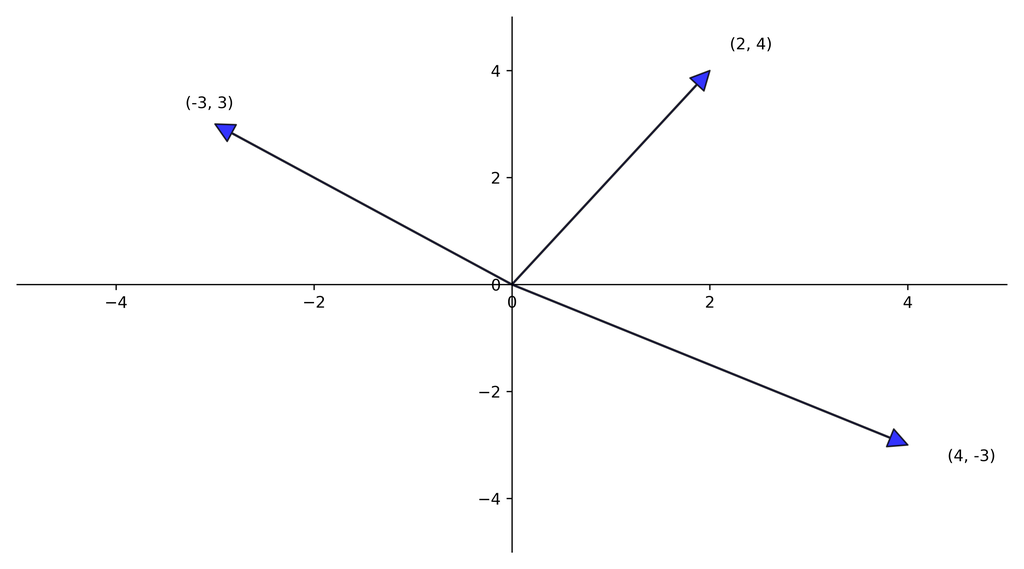

## Vectors

- row vector

$$u=\begin{bmatrix} 1 & 0 \end{bmatrix}$$

- column vector

$$v=\begin{bmatrix} 1 \\ 0 \end{bmatrix}$$

- $v=u^T$

## Vector Operations

- addition and subtraction
  - do the operation element-by-element
  - check the dimension of the vectors

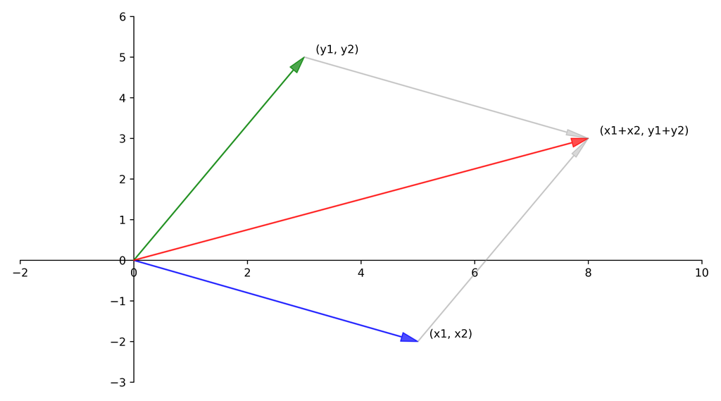

## Vector Operations

- vector multiplication
  - multiply vectors with scalars
  - dot product (inner product)

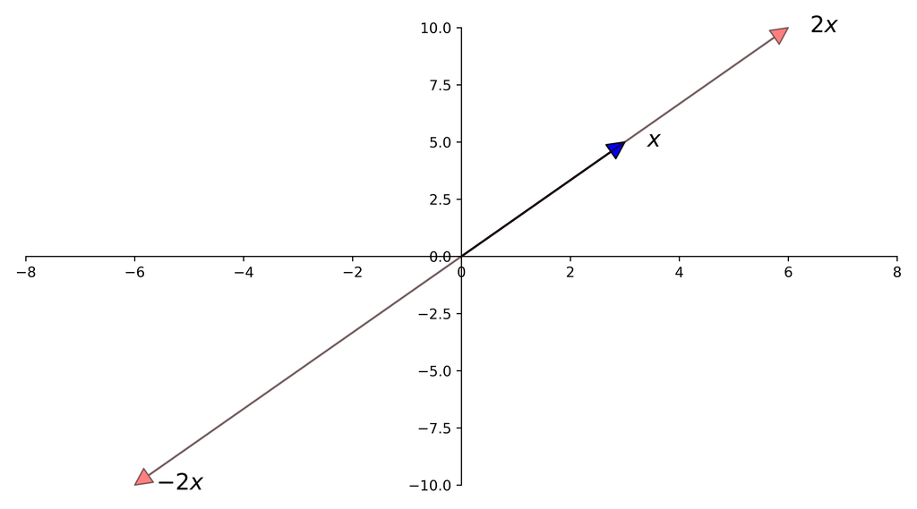

## Vector Operations

The [**dot product**](https://www.mathsisfun.com/algebra/vectors-dot-product.html) of vectors $x,y \in \mathbb R^n$ is defined as

$$\begin{array}{rl}
x^\top y &= {\color{red}{x_1 y_1}} + {\color{blue}{x_2 y_2}} + \cdots + x_n y_n \\
&= \sum_{i=1}^n x_i y_i
\end{array}$$

- the dot product could be written as $x \cdot y$ or $x'y$
- the dot product could be expressed in cosine form

$$x \cdot y = \|x\| \|y\| \cos \theta$$

## Matrix Algebra

- what is a matrix?
  - a matrix is a rectangular array of numbers
  - $A_{m \times n} = \begin{bmatrix} a_{11} & a_{12} & \cdots & a_{1n} \\ a_{21} & a_{22} & \cdots & a_{2n} \\ \vdots & \vdots & \ddots & \vdots \\ a_{m1} & a_{m2} & \cdots & a_{mn} \end{bmatrix}$

## Matrix Algebra

- matrix addition and subtraction
  - $A_{m \times n} \pm B_{m \times n} = C_{m \times n}$
    - e.g. $A = \begin{bmatrix} 1 & 2 \\ 3 & 4 \end{bmatrix}$, $B = \begin{bmatrix} 5 & 6 \\ 7 & 8 \end{bmatrix}$, $A+B = \begin{bmatrix} 6 & 8 \\ 10 & 12 \end{bmatrix}$
  - check the dimension of the matrices
- In general,

$$A + B =
\begin{bmatrix}
a_{11} & \cdots & a_{1k} \\
\vdots & \vdots & \vdots \\
a_{n1} & \cdots & a_{nk}
\end{bmatrix} +
\begin{bmatrix}
b_{11} & \cdots & b_{1k} \\
\vdots & \vdots & \vdots \\
b_{n1} & \cdots & b_{nk}
\end{bmatrix} =
\begin{bmatrix}
a_{11} + b_{11} & \cdots & a_{1k} + b_{1k} \\
\vdots & \vdots & \vdots \\
a_{n1} + b_{n1} & \cdots & a_{nk} + b_{nk}
\end{bmatrix}$$

## Matrix Algebra

- scale multiplication
  - In general for a number $\gamma$ and any matrix $A$,

$$\gamma A =
\gamma
\begin{bmatrix}
a_{11} & \cdots & a_{1k} \\
\vdots & \vdots & \vdots \\
a_{n1} & \cdots & a_{nk}
\end{bmatrix} :=
\begin{bmatrix}
\gamma a_{11} & \cdots & \gamma a_{1k} \\
\vdots & \vdots & \vdots \\
\gamma a_{n1} & \cdots & \gamma a_{nk}
\end{bmatrix}$$

## Matrix multiplication

- The rule for matrix multiplication generalizes the idea of inner products
  - If $A$ is $n \times k$ and $B$ is $j \times m$, then to multiply $A$ and $B$
    - any requirement on the dimensions of $A$ and $B$ for the matrix multiplication?
    - what will be dimension of the resulting matrix $A B$
- Here’s an example of a $2 \times 2$ matrix multiplied by a $2 \times 1$ vector

$$Ax =
\begin{bmatrix}
\color{red}{a_{11}} & \color{red}{a_{12}} \\
a_{21} & a_{22}
\end{bmatrix}
\begin{bmatrix}
\color{red}{x_1} \\
\color{red}{x_2}
\end{bmatrix}
=
\begin{bmatrix}
\color{red}{a_{11}x_1 + a_{12}x_2} \\
a_{21}x_1 + a_{22}x_2
\end{bmatrix}$$

- Here is a simple illustration of multiplication of two matrices

$$AB =
\begin{bmatrix}
a_{11} & a_{12} \\
\color{red}{a_{21}} & \color{red}{a_{22}} \\
\end{bmatrix}
\begin{bmatrix}
b_{11} & \color{red}{b_{12}} \\
b_{21} & \color{red}{b_{22}} \\
\end{bmatrix} :=
\begin{bmatrix}
a_{11}b_{11} + a_{12}b_{21} & a_{11}b_{12} + a_{12}b_{22} \\
a_{21}b_{11} + a_{22}b_{21} & \color{red}{a_{21}b_{12} + a_{22}b_{22}}
\end{bmatrix}$$

## Matrix multiplication

- Notice that $AB \neq BA$ in general
- There are many tutorials to help you further visualize this operation, like [this one](http://www.mathsisfun.com/algebra/matrix-multiplying.html)
- One important special case is the [identity matrix](https://en.wikipedia.org/wiki/Identity_matrix), which has ones on the principal diagonal and zero elsewhere:

$$I = \begin{bmatrix}
1 & \cdots & 0 \\
\vdots & \ddots & \vdots \\
0 & \cdots & 1
\end{bmatrix}$$

- Execises:
  - if $A$ is $n \times k$ and $I$ is the $k \times k$ identity matrix, then $AI = A$
  - if $I$ is the $n \times n$ identity matrix, then $IA = A$

## Exercise

$$Y=\begin{bmatrix} 3 & 1 & -2 \\ 6 & 3 & 4 \end{bmatrix}
, \quad X=\begin{bmatrix} 4 & 2 \\ 3 & 0 \\ 1 & 2 \end{bmatrix}$$

1. What are the dimensions of the matrices $X$ and $Y$?
2. How to multiply $Y$ and $X$ to yield a $3 \times 3$ matrix? Compute it
3. How to multiply $Y$ and $X$ to yield a $2 \times 2$ matrix? Compute it

## Linear Transformation

Matrics as Mapping

- Each $n \times k$ matrix $A$ can be identified with a function $f(x) = Ax$ that maps $x \in \mathbb R ^k$ into $y = Ax \in \mathbb R ^n$
  - these kinds of functions have a special property: they are *linear*
- A function $f \colon \mathbb R ^k \to \mathbb R ^n$ is called *linear* if
  - for all $x, y \in \mathbb R$ and all scalars $\alpha, \beta$, we have

$$f(\alpha x + \beta y) = \alpha f(x) + \beta f(y)$$

- it can be [shown](https://en.wikipedia.org/wiki/Linear_map#Matrices) that $f$ is linear *if and only if* there exists a matrix $A$ such that $f(x) = Ax$ for all $x$

## Linear Transformation

Some examples

We consider how a given matrix transforms in $\mathbb R ^2$

Let $\begin{bmatrix} 2 & 1 \\ -1 & 1 \end{bmatrix}$

- it transforms the vector $x = \begin{bmatrix} 1 \\ 3 \end{bmatrix}$ to the vector $y = \begin{bmatrix} 5 \\ 2 \end{bmatrix}$ through the matrix multiplication

$$\begin{bmatrix}
2 & 1 \\
-1 & 1
\end{bmatrix}
\begin{bmatrix}
1 \\
3
\end{bmatrix}$$

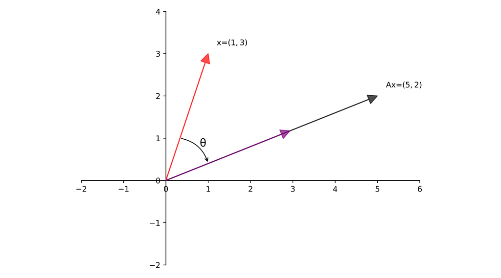

- Ex: with the same vector $x$, now, the matrix becomes $A = \begin{bmatrix} 1 & 2 \\ 3 & 4 \end{bmatrix}$, what will be the $y$?

## Linear Transformation

Some examples - Scaling

A matrix of the form

$$\begin{bmatrix}
\alpha & 0
\\ 0 & \beta
\end{bmatrix}$$

scales vectors across the x-axis by a factor $\alpha$ and along the y-axis by a factor $\beta$

- a simple example where $\alpha = \beta = 3$

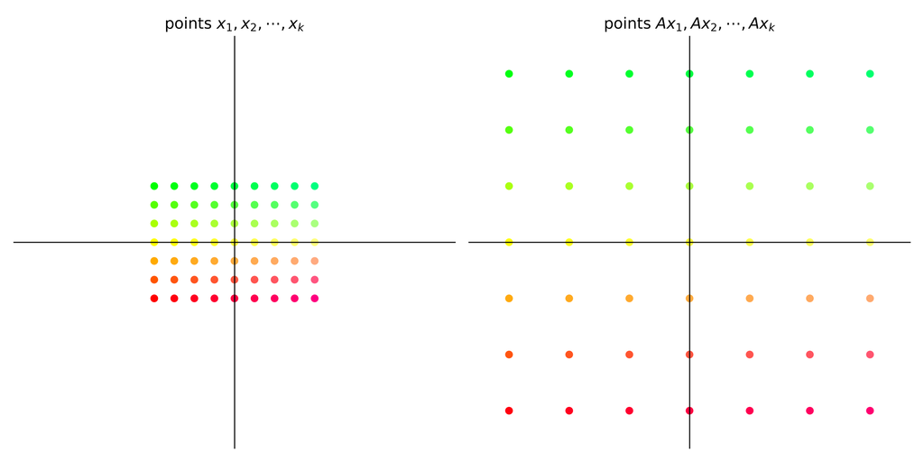

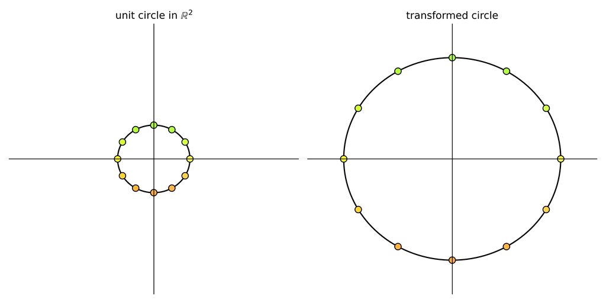

## Linear Transformation

Some examples - Shearing

A “shear” matrix of the form

$$\begin{bmatrix}
1 & \lambda \\
0 & 1
\end{bmatrix}$$

stretches vectors along the x-axis by an amount proportional to the y-coordinate of a point

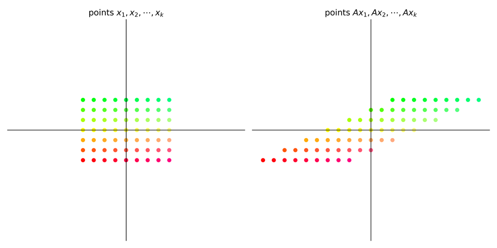

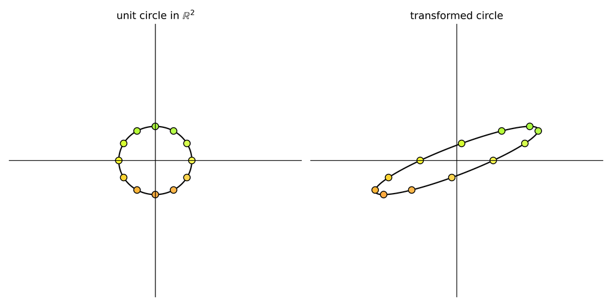

## Linear Transformation

Some examples - Rotation

A matrix of the form

$$\begin{bmatrix}
\cos \theta & \sin \theta
\\ - \sin \theta & \cos \theta
\end{bmatrix}$$

is called a *rotation matrix*

- This matrix rotates vectors clockwise by an angle $\theta$
  - 45 degree clockwise rotation

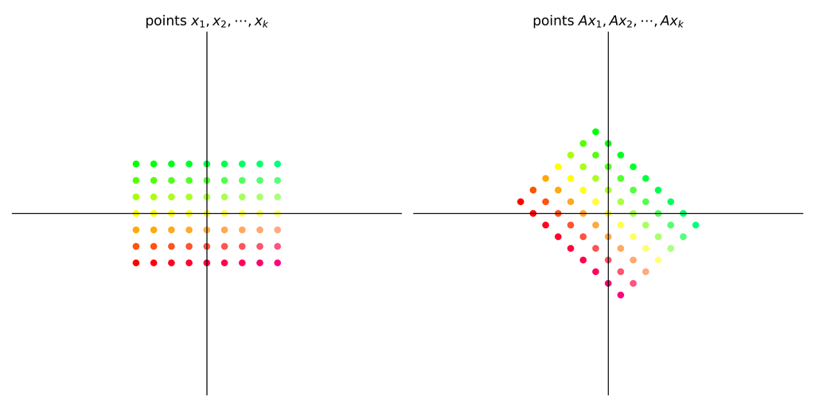

## Linear Transformation

Some examples - Permutation

The permutation matrix

$$\begin{bmatrix}
0 & 1 \\
1 & 0
\end{bmatrix}$$

interchanges the coordinates of a vector

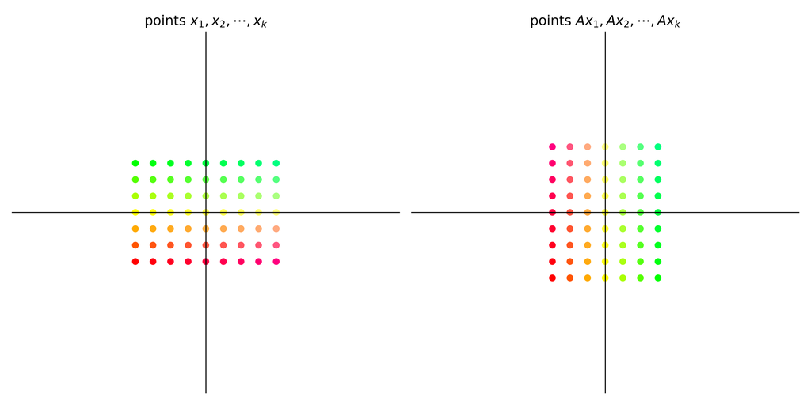

## Matrix multiplication as composition

Linear compositions

Consider the two matrices

$$A =
\begin{bmatrix}
0 & 1 \\
-1 & 0
\end{bmatrix}
\quad \text{and} \quad
B =
\begin{bmatrix}
1 & 2 \\
0 & 1
\end{bmatrix}$$

- What will the output be when we try to obtain $ABx$ for some $2 \times 1$ vector $x$?

$$\color{red}{\underbrace{
\color{black}{\begin{bmatrix}
0 & 1 \\
-1 & 0
\end{bmatrix}}
}_{\textstyle A} }
\color{red}{\underbrace{
\color{black}{\begin{bmatrix}
1 & 2 \\
0 & 1
\end{bmatrix}}
}_{\textstyle B}}
\color{red}{\overbrace{
\color{black}{\begin{bmatrix}
1 \\
3
\end{bmatrix}}
}^{\textstyle x}}
\rightarrow
\color{red}{\underbrace{
\color{black}{\begin{bmatrix}
0 & 1 \\
-1 & -2
\end{bmatrix}}
}_{\textstyle AB}}
\color{red}{\overbrace{
\color{black}{\begin{bmatrix}
1 \\
3
\end{bmatrix}}
}^{\textstyle x}}
\rightarrow
\color{red}{\overbrace{
\color{black}{\begin{bmatrix}
3 \\
-7
\end{bmatrix}}
}^{\textstyle y}}$$

## Matrix multiplication as composition

Linear compositions

$$\color{red}{\underbrace{
\color{black}{\begin{bmatrix}
0 & 1 \\
-1 & 0
\end{bmatrix}}
}_{\textstyle A} }
\color{red}{\underbrace{
\color{black}{\begin{bmatrix}
1 & 2 \\
0 & 1
\end{bmatrix}}
}_{\textstyle B}}
\color{red}{\overbrace{
\color{black}{\begin{bmatrix}
1 \\
3
\end{bmatrix}}
}^{\textstyle x}}
\rightarrow
\color{red}{\underbrace{
\color{black}{\begin{bmatrix}
0 & 1 \\
-1 & 0
\end{bmatrix}}
}_{\textstyle A}}
\color{red}{\overbrace{
\color{black}{\begin{bmatrix}
7 \\
3
\end{bmatrix}}
}^{\textstyle Bx}}
\rightarrow
\color{red}{\overbrace{
\color{black}{\begin{bmatrix}
3 \\
-7
\end{bmatrix}}
}^{\textstyle y}}$$

- We can observe that applying the transformation $AB$ on the vector $x$ is the same as first applying $B$ on $x$ and then applying $A$ on the vector $Bx$.
- the matrix product $AB$ is the composition of the matrix transformations $A$ and $B$
  - first apply transformation $B$ and then transformation $A$
- notice that $AB$ is generally not equal to $BA$

## Matrix multiplication as composition

Linear compositions - examples

- Let $A$ be the $90^{\circ}$ clockwise rotation matrix given by $\begin{bmatrix} 0 & 1 \\ -1 & 0 \end{bmatrix}$
- Let $B$ be a shear matrix along the x-axis given by $\begin{bmatrix} 1 & 2 \\ 0 & 1 \end{bmatrix}$
- visualize how a grid of points changes when we apply the transformation $AB$ and then compare it with the transformation $BA$

## Matrix multiplication as composition

Linear compositions - examples

Shear then rotate

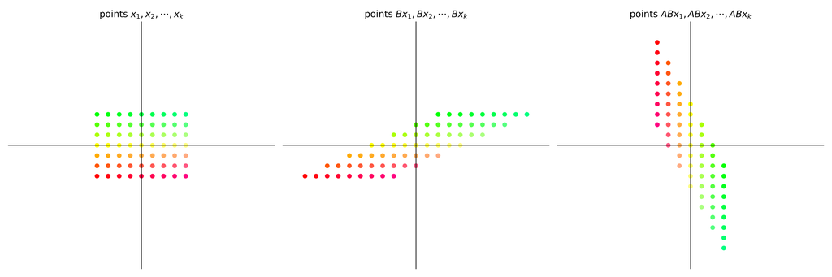

## Matrix multiplication as composition

Linear compositions - examples

Rotate then shear

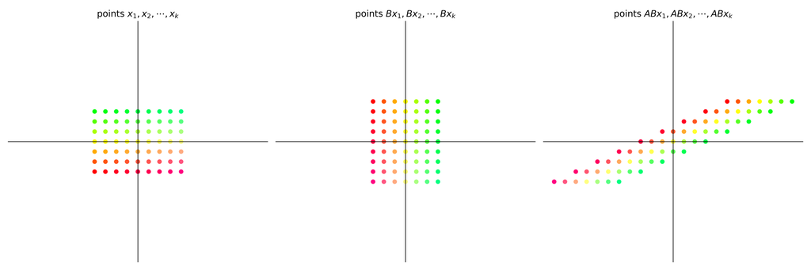

- it demonstrates that the transformation $AB$ is not the same as the transformation $BA$

## Matrix multiplication as composition

Linear compositions - Iterating on a fixed map

In economics, we are often interested in analyzing behavior where we repeatedly apply a fixed matrix

For example, given a vector $v$ and a matrix $A$, we are interested in studying the sequence

$$v, \quad
Av, \quad
AAv = A^2v, \quad \ldots$$

## Matrix multiplication as composition

Linear compositions - Iterating on a fixed map

- Example of a sequence of iterates $(A^k v)_{k \geq 0}$ under map $A=\begin{bmatrix} \sqrt{3}+1 & -2 \\ 1 & \sqrt{3}-1 \end{bmatrix}$
- let $v = (-3, -3)$

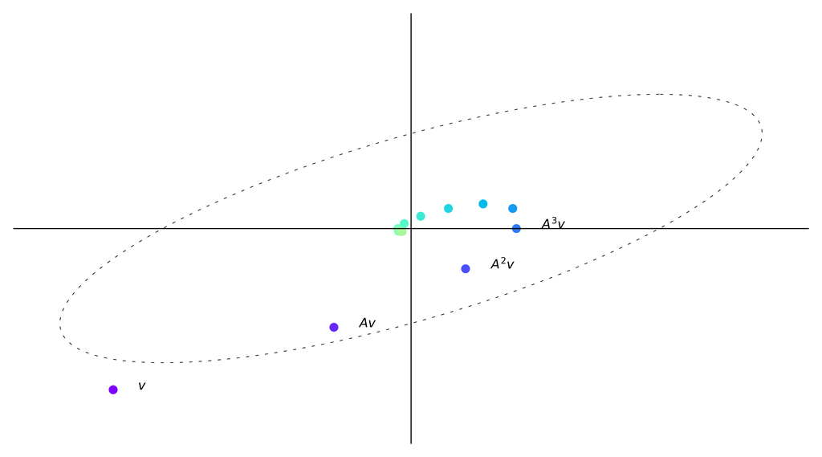

## Matrix multiplication as composition

Linear compositions - Iterating on a fixed map

- Example of a sequence of iterates $(A^k v)_{k \geq 0}$ under map $A=\begin{bmatrix} \sqrt{3}+1 & -2 \\ 1 & \sqrt{3}-1 \end{bmatrix}$
- let $v = (2.5, 0)$

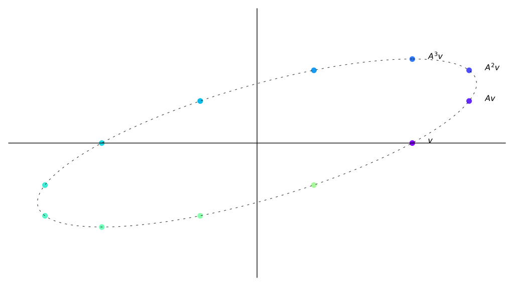

- In this case, repeatedly multiplying a vector by $A$ simply “rotates it around an ellipse”

## Matrix multiplication as composition

Linear compositions - Iterating on a fixed map

- Example of a sequence of iterates $(A^k v)_{k \geq 0}$ under map $A=\begin{bmatrix} \sqrt{3}+1 & -2 \\ 1 & \sqrt{3}-1 \end{bmatrix}$
- let $v = (-1, -0.25)$

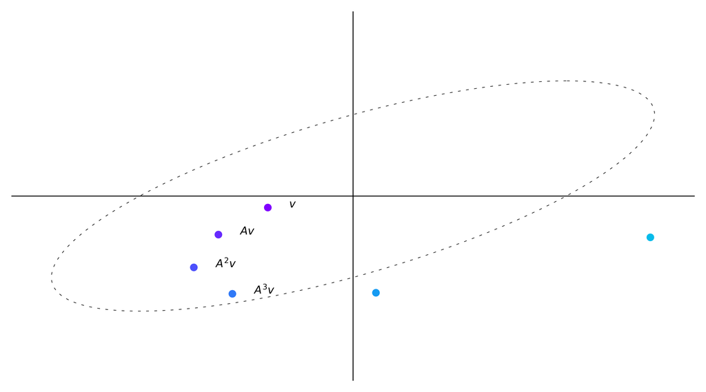

- In this case, repeatedly multiplying a vector by $A$ makes the vector “spiral out”

## System of Linear Equations

- Two equations in two unknowns

$$\begin{aligned}
y_1 = a x_1 + b x_2 \\
y_2 = c x_1 + d x_2
\end{aligned}$$

- How we solve it?
  - substitution and elimination
- Let us work on a simple example

$$\begin{aligned}
3x + 5y &= 7 \\
x - 2y &= 3
\end{aligned}$$

- what are $x$ and $y$?

## General linear systems

A more general version looks as follows

$$\begin{matrix}
a_{11} x_1 & + & a_{12} x_2 & + & \cdots & + & a_{1n} x_n & = & b_1 \\
\vdots & & \vdots & & & & \vdots & & \vdots \\
a_{n1} x_1 & + & a_{n2} x_2 & + & \cdots & + & a_{nn} x_n & = & b_n
\end{matrix}$$

- The objective here is to solve for the “unknowns” $x_1, \ldots, x_n$
- We take as given the coefficients $a_{11}, \ldots, a_{nn}$ and constants $b_1, \ldots, b_n$
- this is a setting where the number of unknowns equals the number of equations
  - this is the case where we are most likely to find a well-defined solution

## Solving systems of equations

$$A x = b
\quad \text{where} \quad
A =
\begin{bmatrix}
a_{11} & \cdots & a_{1n} \\
\vdots & \vdots & \vdots \\
a_{n1} & \cdots & a_{nn}
\end{bmatrix}
\quad \text{and} \quad
b =
\begin{bmatrix}
b_1 \\
\vdots \\
b_n
\end{bmatrix}$$

- find a vector $x \in \mathbb R^n$ that solves the equations, taking $b$ and $A$ as given

## Some examples

Consider the system of equations given by

$$\begin{aligned}
x + 3y &= 3 \\
2x + 6y &= -8
\end{aligned}$$

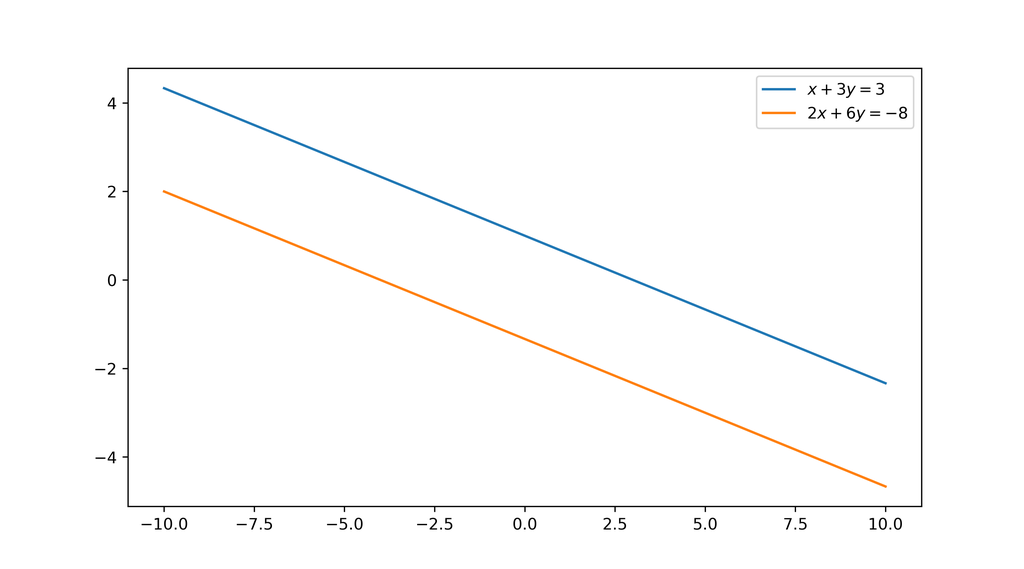

## Some examples

Consider the system of equations given by

$$\begin{aligned}
x - 2y &= -4 \\
-2x + 4y &= 8
\end{aligned}$$

Any vector $v = (x,y)$ such that $x = 2y - 4$ will solve the above system

Since we can find infinite such vectors this system has infinitely many solutions

This is because the rows of the corresponding matrix are linearly dependent

## Nonsingular matrices

- A square matrix $A$ is nonsingular if and only if the rows and columns of $A$ are linearly independent
- To every square matrix we can assign a unique number called the [determinant](https://en.wikipedia.org/wiki/Determinant).
- For $2 \times 2$ matrices, the determinant is given by,

$$\begin{bmatrix}
\color{red}{a} & \color{blue}{b} \\
\color{blue}{c} & \color{red}{d}
\end{bmatrix}
=
{\color{red}{ad}} - {\color{blue}{bc}}$$

- the determinant of a $3 \times 3$ matrix

$$det \begin{bmatrix}
a & b & c \\
d & e & f \\
g & h & i
\end{bmatrix}
= a(ei - fh) - b(di - fg) + c(dh - eg)$$

- If the determinant of $A$ is not zero, then we say that $A$ is *nonsingular*

## Nonsingular matrices

- a square matrix $A$ has a nonzero determinant, if and only if it possesses an *inverse matrix* $A^{-1}$, with the property that $A A^{-1} =A^{-1} A = I$.
- As a consequence, if we pre-multiply both sides of $Ax = b$ by $A^{-1}$, we get

$$x = A^{-1} b$$

This is the solution to $Ax = b$ — the solution we are looking for

- A more detailed explanation of matrix inverse can be found [here](https://www.mathsisfun.com/algebra/matrix-inverse.html)

## When the matrices have more rows than columns

$A_{n \times k}$ matrix with $n > k$

- this is important in many settings, including linear regression
- Given arbitrary $y \in \mathbb R ^n$, we seek an $x \in \mathbb R ^k$ such that $y = Ax$
  - the existence of a solution is highly unlikely
- focusing on the case where the columns of $A$ are linearly independent.
  - the span of the columns of $A$ is a $k$-dimensional subspace of $\mathbb R ^n$.
- in the $n > k$ case we usually give up on existence
  - instead, seek the best approximation, looking for $x$ that makes the distance $\| y - Ax\|$ as small as possible
  - one can use either calculus or the theory of orthogonal projections

$A_{n \times k}$ matrix with $n < k$

- there are either no solutions or infinitely many — in other words, uniqueness never holds
- For example, consider the case where $k=3$ and $n=2$
  - the columns of $A$ consists of 3 vectors in $\mathbb R ^2$
  - this set can never be linearly independent
  - hence, one column is a linear combination of the other two
  - let’s say that $a_1 = \alpha a_2 + \beta a_3$
  - then if $y = Ax = x_1 a_1 + x_2 a_2 + x_3 a_3$, we can also write

$$y
= x_1 (\alpha a_2 + \beta a_3) + x_2 a_2 + x_3 a_3
= (x_1 \alpha + x_2) a_2 + (x_1 \beta + x_3) a_3$$

## Positive Definite Matrices

Let $A$ be a symmetric $n \times n$ matrix

- $A$ is
  1. *positive definite* if $x' A x > 0$ for every $x \in \mathbb R ^n \setminus \{0\}$
  2. *positive semi-definite* or *nonnegative definite* if $x' A x \geq 0$ for every $x \in \mathbb R ^n$
- Analogous definitions exist for negative definite and negative semi-definite matrices
- if $A$ is positive definite, then all of its eigenvalues are strictly positive
  - hence $A$ is invertible (with positive definite inverse)

## References

Stachurski, John. 2016. *A Primer in Econometric Theory*. Cambridge, Massachusetts: The MIT Press.